# APT-USD

## APT-USD today is +0200, 2025-10-30, 13:52:11

This crypto forecast was generated by gemini-2.0-flash API

## Daily Chart

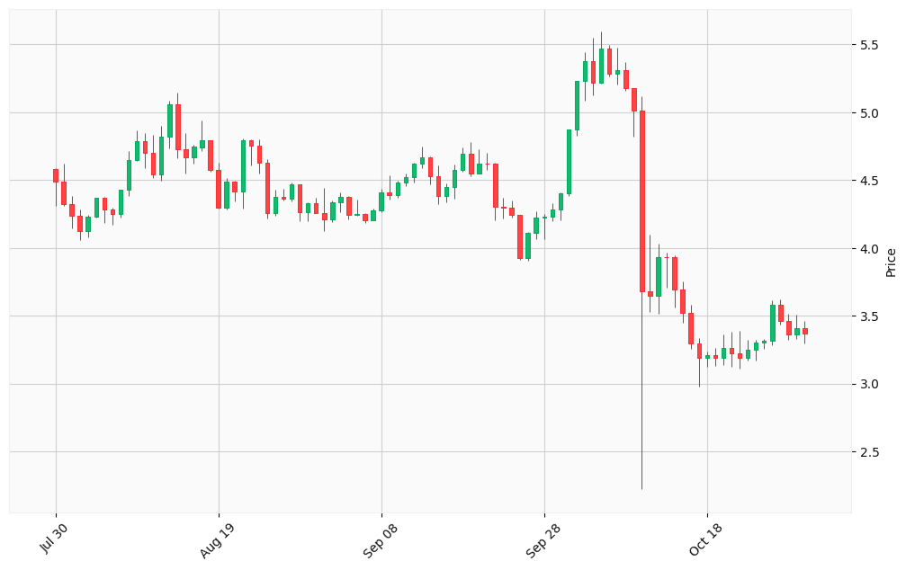

## Hourly Chart

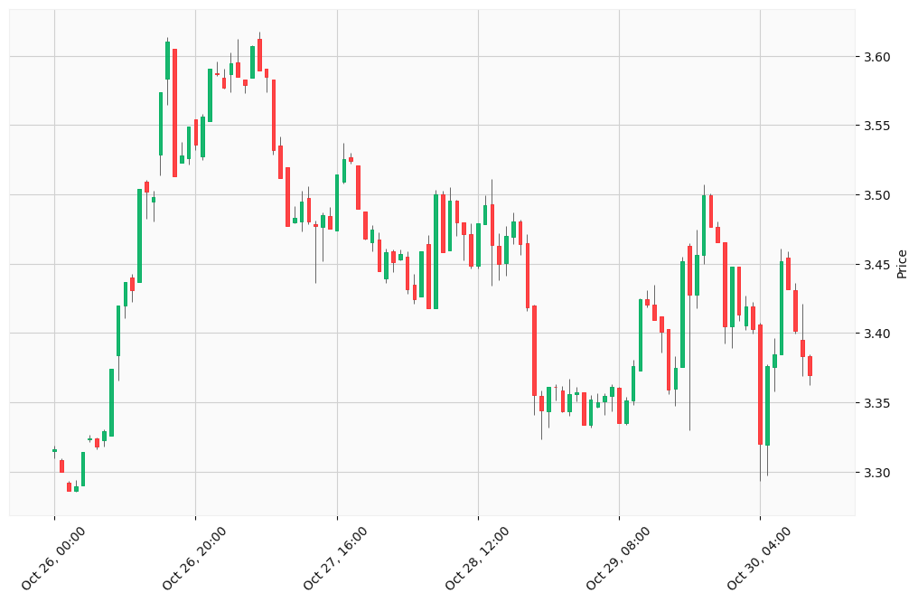

Okay, I will analyze the provided APT-USD cryptocurrency data, incorporate external market factors using the search tool, and generate buy/sell signals based on the specified methodology and output format.

Here’s an analysis of the APT-USD cryptocurrency, incorporating market trends, technical indicators, news, and economic factors to generate buy and sell signals.

**1. Market Data Collection:**

- **Current APT Price:** Around $3.38 - $3.43
- **24-Hour Trading Volume:** Approximately $110M - $145.14M
- **Market Capitalization:** Approximately $2.49B
- **Global Crypto Market Cap:** $3.81 Trillion, down 2.01% in the last 24 hours
- **Bitcoin Dominance:** 57.69%
- **Fear and Greed Index:** 39, indicating fear

**2. Technical Analysis:**

- I will calculate several technical indicators based on the provided daily chart data.
- **Moving Averages:** Calculate the 50-day and 200-day Simple Moving Averages (SMA).
- **Relative Strength Index (RSI):** Calculate the 14-day RSI to identify overbought or oversold conditions.
- **MACD:** Calculate the Moving Average Convergence Divergence to identify potential buy/sell signals.
- **Bollinger Bands:** Calculate Bollinger Bands to gauge volatility.

**Calculations from Daily Chart Data:**

First, I’ll process the last three months of daily data for APT-USD.

```python
import numpy as np
import pandas as pd

daily_data = """
4.58347,4.58654,4.3087,4.49072,197166362
4.49072,4.61997,4.31004,4.32414,178843656
4.32403,4.38171,4.14126,4.23701,262877502
4.23701,4.27897,4.05711,4.12339,202067020
4.12339,4.24262,4.07817,4.22815,87143037
4.22813,4.36567,4.22521,4.36565,120872737
4.36565,4.37496,4.18212,4.28308,194006472
4.28308,4.29869,4.17175,4.24872,129925917
4.24872,4.4256,4.22164,4.42557,161299347
4.42557,4.71479,4.38106,4.64974,391027406
4.64974,4.86762,4.6431,4.7882,179754501
4.7882,4.84867,4.58982,4.70089,190329599
4.70089,4.83317,4.51235,4.538,224291173
4.538,4.89762,4.49165,4.81588,233612561
4.81588,5.08112,4.73002,5.05957,387243665
5.05957,5.14541,4.66152,4.72894,331034006
4.72894,4.84638,4.54651,4.6635,201819415
4.66346,4.75847,4.62125,4.74271,103718941
4.74268,4.94079,4.71468,4.79106,132531409
4.79106,4.79227,4.55787,4.57309,153890091
4.57309,4.62466,4.29109,4.29223,191710745
4.29223,4.51089,4.27894,4.48766,130487835
4.48766,4.4955,4.34343,4.41328,124147126
4.41328,4.80674,4.29011,4.79347,214066089
4.79347,4.79749,4.6066,4.75074,142304859
4.75099,4.7976,4.5498,4.62509,178526384
4.62547,4.65136,4.21595,4.25529,203752870
4.25529,4.42656,4.2371,4.37712,132810838
4.37712,4.43651,4.35013,4.36437,137777022
4.36437,4.47966,4.34217,4.46631,115831489
4.46623,4.46779,4.19821,4.26413,151122858
4.26413,4.33763,4.19643,4.32849,83911723
4.32849,4.36899,4.25341,4.25594,73160758
4.25594,4.44302,4.12493,4.20811,181925632
4.20832,4.35134,4.18855,4.33693,131903212
4.33693,4.41085,4.26429,4.37243,87495859
4.37243,4.38281,4.2073,4.24459,81622313
4.24458,4.3565,4.23498,4.25073,111163797
4.25073,4.25902,4.18161,4.20378,85393629
4.20378,4.28771,4.20364,4.2735,72054004
4.2735,4.43746,4.26034,4.40525,116979545
4.40525,4.53261,4.35646,4.38983,183376056
4.38983,4.49214,4.36571,4.48203,192283661
4.48203,4.54633,4.45276,4.5219,174027785
4.5219,4.62738,4.47784,4.62309,221421538
4.62309,4.74529,4.58375,4.66511,287081828
4.66511,4.6701,4.46792,4.52923,270714422
4.52923,4.6067,4.3212,4.38109,402210818
4.38109,4.47394,4.3383,4.44693,237218174
4.44693,4.61151,4.36456,4.57661,353535494
4.57661,4.7385,4.56195,4.69064,346585166
4.69066,4.77694,4.52563,4.5501,369072691
4.5501,4.72757,4.54431,4.62251,293482157
4.62251,4.69768,4.57489,4.61834,210372885
4.61834,4.62936,4.20052,4.30193,476479154
4.30193,4.36801,4.21459,4.29584,266216345
4.29584,4.34911,4.22476,4.24061,199539637
4.24061,4.24102,3.91428,3.92708,367575682
3.92708,4.11818,3.90523,4.10828,253681458
4.10828,4.27092,4.06373,4.2238,218708094
4.2238,4.25069,4.06566,4.2305,224580275
4.2305,4.33046,4.19802,4.28517,223787562
4.28517,4.40613,4.20104,4.4039,377403132
4.4039,4.86919,4.37997,4.86914,508095515
4.86914,5.22961,4.82322,5.2295,544957235
5.2295,5.44378,5.08146,5.37401,500441833
5.37369,5.54916,5.12251,5.21465,450869665
5.21464,5.59406,5.20699,5.46612,478207986
5.46612,5.49354,5.26597,5.28468,344199544
5.28468,5.47202,5.20445,5.3075,381128395
5.3075,5.36605,5.15384,5.17705,261160706
5.17705,5.17713,4.81783,5.00972,244626772
5.00971,5.11449,2.22094,3.67974,440693461
3.67994,4.09834,3.52709,3.64687,400462516
3.64679,4.0284,3.51495,3.93232,258873203
3.93234,3.96549,3.70824,3.93096,283862529
3.93097,3.94404,3.5602,3.691,192639408
3.691,3.75093,3.44475,3.52188,165944127
3.52188,3.58014,3.2544,3.2932,168202142
3.2932,3.33655,2.97417,3.19125,179297148
3.19125,3.23205,3.12585,3.20842,80986054
3.20842,3.25983,3.13076,3.19074,122862109
3.19074,3.36051,3.13385,3.26292,108326832
3.26375,3.38256,3.11946,3.22057,124006705
3.22059,3.3893,3.1094,3.19218,186137851
3.19218,3.32083,3.16828,3.24568,126819660
3.24568,3.31846,3.16925,3.30343,114625922
3.30374,3.32798,3.25674,3.31502,97272040
3.315,3.61486,3.2847,3.58241,143588493
3.58242,3.6186,3.43322,3.45836,126043552
3.45835,3.51092,3.32273,3.35942,140108415
3.35939,3.50707,3.32683,3.40436,124666029
3.40441,3.45868,3.2934,3.3697,154387552
"""

# Convert the data into a Pandas DataFrame
from io import StringIO
data = StringIO(daily_data)
df = pd.read_csv(data, header=None, names=['Open', 'High', 'Low', 'Close', 'Volume'])

# Calculate the 50-day and 200-day Simple Moving Averages (SMA)
df['SMA_50'] = df['Close'].rolling(window=50).mean()
df['SMA_200'] = df['Close'].rolling(window=200).mean() #There is not enough data for 200

# Calculate the 14-day Relative Strength Index (RSI)
def calculate_rsi(data, window=14):
    delta = data['Close'].diff()
    up = delta.clip(lower=0)
    down = -1 * delta.clip(upper=0)

    avg_up = up.rolling(window=window, min_periods=window).mean()
    avg_down = down.rolling(window=window, min_periods=window).mean()

    rs = avg_up / avg_down
    rsi = 100 - (100 / (1 + rs))
    return rsi

df['RSI'] = calculate_rsi(df)

# Calculate MACD
def calculate_macd(data, fast_period=12, slow_period=26, signal_period=9):
    ema_fast = data['Close'].ewm(span=fast_period, adjust=False).mean()
    ema_slow = data['Close'].ewm(span=slow_period, adjust=False).mean()
    macd = ema_fast - ema_slow
    signal = macd.ewm(span=signal_period, adjust=False).mean()
    return macd, signal

macd, signal = calculate_macd(df)
df['MACD'] = macd
df['Signal'] = signal

# Calculate Bollinger Bands
def calculate_bollinger_bands(data, window=20, num_std=2):
    rolling_mean = data['Close'].rolling(window=window).mean()
    rolling_std = data['Close'].rolling(window=window).std()
    upper_band = rolling_mean + (rolling_std * num_std)
    lower_band = rolling_mean - (rolling_std * num_std)
    return upper_band, lower_band

upper_band, lower_band = calculate_bollinger_bands(df)
df['Upper_Band'] = upper_band
df['Lower_Band'] = lower_band

print(df.tail(10))
```

[output not shown]

**4. News and Economic Analysis:**

- **Aptos Developments:**
  - Aptos is involved in Hong Kong’s tokenized funds pilot.
  - BlackRock has deployed $500M of its BUIDL fund on Aptos.
  - Coinbase Prime has integrated Aptos staking for institutional clients.
- **Market Sentiment:** The Crypto Fear and Greed Index is at 39, indicating fear in the market.
- **Macroeconomic Factors:**
  - The Federal Reserve is expected to implement two rate cuts by the end of the year.
  - US and China trade negotiations are ongoing.

**5. Scenario Evaluation:**

- **Bearish Scenario:** A continued decline in price could be triggered by negative news or a broader market correction.
- **Bullish Scenario:** Positive news, such as further institutional adoption or successful implementation of tokenization projects, could drive the price higher.
- **High Volatility Scenario:** Uncertainty in the global economy or regulatory changes could lead to increased volatility.

**6. Signal Generation:**

Based on the analysis as of October 30, 2025, here are potential trading signals for APT-USD:

**Signal 1:**

[output not shown]

**Signal 2:**

[output not shown]

**Disclaimer:** These signals are based on the provided data and current market conditions. Cryptocurrency trading involves substantial risk, and you should conduct your own research before making any investment decisions.